# Yeast scRNA-seq TF KO

## Nitrogen limitation and the TOR signaling pathway

```r
## line plots
nitroTFs <- c("GAT1", "GLN3", "RTG1", "RTG3")
all(nitroTFs %in% mapID$Name)
```

```
## [1] TRUE
```

```r
tfGRN <- data.frame(sys=colnames(X),
                    name=mapID$Name[match(colnames(X), mapID$SystematicName)])
nitroTFGRN <- tfGRN[tfGRN$name %in% nitroTFs,]
rownames(nitroTFGRN) <- nitroTFGRN$name
nitroTFGRN <- nitroTFGRN[nitroTFs,]
all(nitroTFs %in% nitroTFGRN$name)
```

```
## [1] TRUE
```

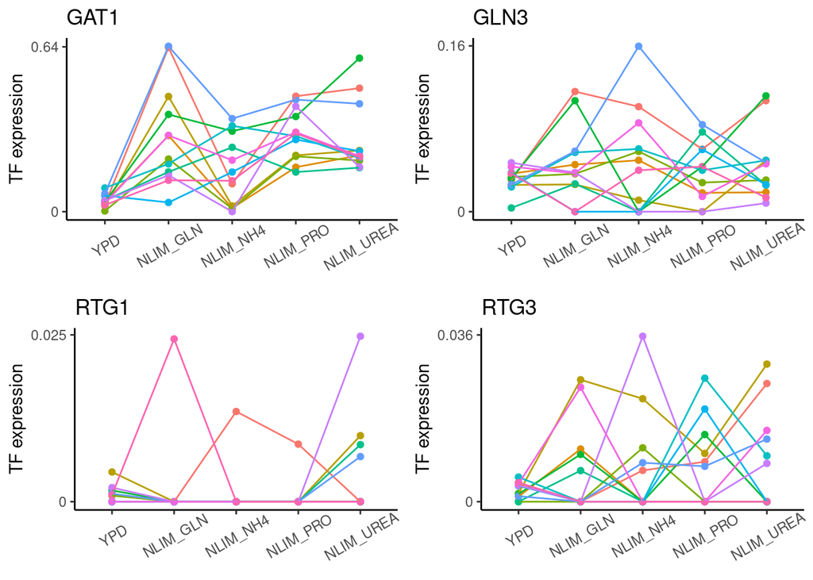

```r
ypdColumns <- grep(x = colnames(design),
                       pattern = "YPD$")
nitroColumns <- grep(x = colnames(design),
                       pattern = "NLIM_")
pListNitro_exp <- list()
for(kk in 1:nrow(nitroTFGRN)){
  curTF <- nitroTFGRN$sys[kk]
  ypd <- dataMean[ypdColumns, curTF]
  nitro <- dataMean[nitroColumns, curTF]
  df <- data.frame(expression = c(ypd, nitro),
                   condition = factor(rep(c("YPD", "NLIM_GLN", "NLIM_NH4", "NLIM_PRO", "NLIM_UREA"), each=length(ypd), levels=c("YPD", "NLIM_GLN", "NLIM_NH4", "NLIM_PRO", "NLIM_UREA"))),
                   genotype = factor(rep(1:nlevels(factor(genotype)), 5)))
  p <- ggplot(df, aes(x=condition, y=expression, group=genotype, col=genotype)) +
    geom_point() +
    geom_line() +
    ggtitle(nitroTFGRN$name[kk]) +
    theme_classic() +
    theme(legend.position = "none") +
    xlab(NULL) +
    scale_y_continuous(name = "TF expression",
                       breaks = signif(c(min(df$expression), max(df$expression)), 2),
                       labels = signif(c(min(df$expression), max(df$expression)), 2)) +
    scale_x_discrete(limits=c("YPD", "NLIM_GLN", "NLIM_NH4", "NLIM_PRO", "NLIM_UREA")) +
    theme(axis.text.x = element_text(angle = 30, vjust= 0.7, size=9))
  #print(p)
  pListNitro_exp[[kk]] <- p
}
cowplot::plot_grid(plotlist = pListNitro_exp)
```

```r
ggsave("../plots/241127_nitrogen_tfExpression.pdf", width=8, height=7)
```

### Combined plot

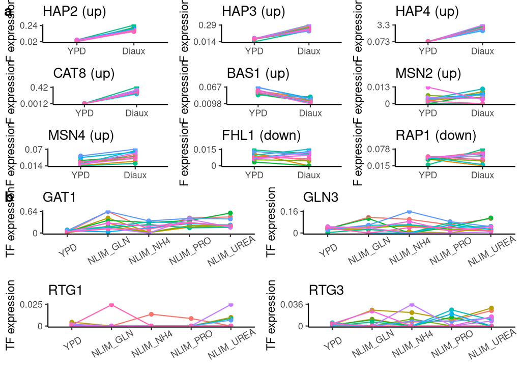

```r
pDi <- cowplot::plot_grid(plotlist = pListDiaux_exp)
pNi <- cowplot::plot_grid(plotlist = pListNitro_exp)
cowplot::plot_grid(pDi, pNi, labels=c("a","b"), nrow=2)
```

```r
ggsave("../plots/241127_TfExpression_composite.pdf", width=8, height=10)
```

# Unsupervised TF activity estimation

Here, we compare our results on TF activity to those of `viper` and `AUCell`. Note, that `viper` and `AUCell` work unsupervised, i.e., they do not use information on the conditions nor genotypes. We will approximate this by allowing each combination of 10 cells to be its own group. For `viper` and `AUCell`, we will sum the counts of those 10 cells.

```r
set.seed(44)
genoCond10 <- as.character(genoCond)
for(gg in 1:nlevels(genoCond)){
  curGenoCond10 <- sample(rep(1:ceiling(table(genoCond)[gg] / 10), each=10)[1:table(genoCond)[gg]])
  genoCond10[genoCond10 == levels(genoCond)[gg]] <- paste0(levels(genoCond)[gg],curGenoCond10)
}
genoCond10f <- factor(genoCond10)
design10 <- model.matrix(~ 0 + genoCond10f)
```

```r
poisRes_repr_design10 <- transfactor::estimateActivity(counts = counts,
                                                   X = X,
                                                   model = "poisson",
                                                   U = design10,
                                                   plot = TRUE,
                                                   verbose = TRUE,
                                                   maxIter = 1000,
                                                   epsilon = 1,
                                                   sparse = FALSE,
                                                   repressions = TRUE)
# converged after iteration 90. Log-lik: -94708908.558
saveRDS(poisRes_repr_design10, file="../data/241126_poisRes_repr_design10Cells_domino.rds")
```

## viper and AUCell

```r
library(viper)
library(AUCell)
library(GSEABase)
library(tidyverse)
```

```r
counts10 <- counts %*% design10

constructViperRegulon <- function(X, alpha){
  tfAll <- unlist(mapply(rep, colnames(X), each=colSums(abs(X))))
  targetAll <- rownames(X)[unlist(apply(abs(X),2, function(x) which(x > 0)))]
  mor <- X[abs(X)>0]
  alphaAll <- alpha[abs(X)>0] / max(alpha)
  dfReg <- data.frame(tf=tfAll,
                      target=targetAll,
                      mor=X[abs(X)>0],
                      likelihood=alphaAll)
  dfReg <- dfReg[!duplicated(dfReg),]
  dfReg$tf <- as.character(dfReg$tf)
  dfReg$target <- as.character(dfReg$target)
  regulon <- dorothea:::df2regulon(dfReg)
  return(regulon)
}

constructGenesets <- function(X, alpha){
  tfAll <- unlist(mapply(rep, colnames(X), each=colSums(abs(X))))
  targetAll <- rownames(X)[unlist(apply(abs(X),2, function(x) which(x > 0)))]
  mor <- X[abs(X)>0]
  alphaAll <- alpha[abs(X)>0] / max(alpha)
  dfReg <- data.frame(tf=tfAll,
                      target=targetAll,
                      mor=X[abs(X)>0],
                      likelihood=alphaAll)
  dfReg <- dfReg[!duplicated(dfReg),]
  dfReg$tf <- as.character(dfReg$tf)
  dfReg$target <- as.character(dfReg$target)
  genesets = dfReg %>%
    group_by(tf) %>%
    summarise(geneset = list(GSEABase::GeneSet(target))) %>%
    transmute(tf, geneset2 = pmap(., .f=function(tf, geneset, ...) {
      setName(geneset) = tf
      return(geneset)
    })) %>%
    deframe() %>%
    GeneSetCollection()
}

regulon <- constructViperRegulon(X, alpha=X)
viperRes <- viper(counts10,
                    regulon,
                    nes = TRUE,
                    method = "scale",
                    minsize = 2,
                    eset.filter = F,
                    adaptive.size = F)
```

```
##
## Computing the association scores
## Computing regulons enrichment with aREA
```

[output not shown]

```r
viperRes <- viperRes[colnames(X)[colnames(X) %in% rownames(viperRes)],]

genesets <- constructGenesets(X, alpha = X)
obj <- AUCell_buildRankings(t(scale(t(counts10))), nCores=1,
                            plotStats = F, verbose = F) %>%
  AUCell_calcAUC(genesets, ., verbose=F)
resAUCell <- AUCell::getAUC(obj)
resAUCell <- resAUCell[colnames(X),]
```

## Dimensionality reduction

```r
poisRes_repr_design10 <- readRDS("../data/241126_poisRes_repr_design10Cells_domino.rds")
library(scater)
```

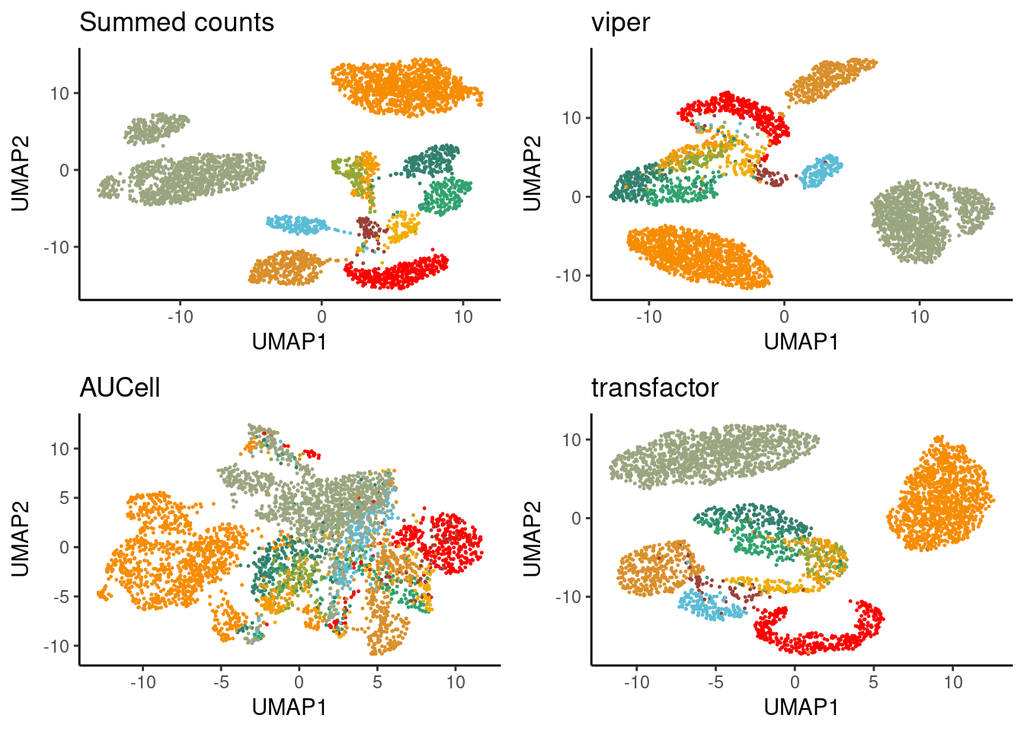

```r
set.seed(44)
pcViper <- scater::calculatePCA(x = viperRes,
                               ncomponents = 10,
                               ntop = nrow(viperRes))
pcAUCell <- scater::calculatePCA(x = resAUCell,
                               ncomponents = 10,
                               ntop = nrow(resAUCell))
pcPois <- scater::calculatePCA(x = poisRes_repr_design10$mu_tc,
                               ncomponents = 10,
                               ntop = ncol(X))
pcOrig10 <- scater::calculatePCA(x = log1p(counts10),
                               ncomponents = 10,
                               ntop = ncol(X))
pcOrig <- scater::calculatePCA(x = log1p(counts),
                               ncomponents = 10,
                               ntop = ncol(X))


umapViper <- uwot::umap(pcViper, min_dist = 0.8)
umapAUCell <- uwot::umap(pcAUCell, min_dist = 0.8)
umapPois <- uwot::umap(pcPois, min_dist = 0.8)
umapOrig10 <- uwot::umap(pcOrig10, min_dist = 0.8)
umapOrig <- uwot::umap(pcOrig, min_dist = 0.8)


plotUMAP <- function(dr, group, main=NULL){
  pal <- wesanderson::wes_palette("Darjeeling1", n=nlevels(cond10), type="continuous")
  df <- data.frame(UMAP1=dr[,1],
                   UMAP2=dr[,2],
                   group=group)
  ggplot(df, aes(x=UMAP1, y=UMAP2, color=group)) +
    geom_point(size=.2) +
    scale_color_manual(values=pal) +
    theme_classic() +
    theme(legend.position = "none") +
    ggtitle(main)
}

# Return legend for one plot
.get_legend <- function(p, position = NULL){

  if(is.null(p)) return(NULL)
  if(!is.null(position)){
    p <- p + theme(legend.position = position)
  }
  tmp <- ggplot_gtable(ggplot_build(p))
  leg <- which(sapply(tmp$grobs, function(x) x$name) == "guide-box")
  if(length(leg) > 0) leg <- tmp$grobs[[leg]]
  else leg <- NULL
  leg
}

getLegend <- function(dr, group, main=NULL){
  pal <- wesanderson::wes_palette("Darjeeling1", n=nlevels(cond10), type="continuous")
  df <- data.frame(UMAP1=dr[,1],
                   UMAP2=dr[,2],
                   group=group)
  tmpPlot <- ggplot(df, aes(x=UMAP1, y=UMAP2, color=group)) +
    geom_point(size=.2) +
    scale_color_manual(values=pal) +
    theme_classic() +
    ggtitle(main) +
    guides(color=guide_legend(nrow=3, ncol=5,
                              title = "condition",
                              override.aes = list(size=3)))
  leg <- .get_legend(tmpPlot)
  return(leg)
}

cond10 <- factor(gsub(x=unlist(lapply(strsplit(colnames(design10), split=","), "[[", 2)),
     pattern="[0-9]+",
     replacement=""))
geno10 <- factor(unlist(lapply(strsplit(genoCond10, split=","), "[[", 1)))
pOrig10 <- plotUMAP(umapOrig10, cond10, main="Summed counts")
pViper <- plotUMAP(umapViper, cond10, main="viper")
pAUCell <- plotUMAP(umapAUCell, cond10, main="AUCell")
pTransfactor <- plotUMAP(umapPois, cond10, main="transfactor")
pOrig <- plotUMAP(umapOrig, condition, main="original counts")
leg <- getLegend(umapPois, cond10)
pDR <- cowplot::plot_grid(pOrig10, pViper, pAUCell, pTransfactor)
pDR
```

```r
## Graph-based clustering to compare
library(scran) ; library(bluster)
clustViper <- clusterRows(umapViper, NNGraphParam(cluster.fun="louvain"))
clustAUCell <- clusterRows(umapAUCell, NNGraphParam(cluster.fun="louvain"))
clustPois <- clusterRows(umapPois, NNGraphParam(cluster.fun="louvain"))
clustOrig10 <- clusterRows(umapOrig10, NNGraphParam(cluster.fun="louvain"))
mclust::adjustedRandIndex(clustViper, cond10)
```

```
## [1] 0.3054368
```

```r
mclust::adjustedRandIndex(clustAUCell, cond10)
```

```
## [1] 0.220716
```

```r
mclust::adjustedRandIndex(clustPois, cond10)
```

```
## [1] 0.3105386
```

```r
mclust::adjustedRandIndex(clustOrig10, cond10)
```

```
## [1] 0.3466034
```

# Composite figure

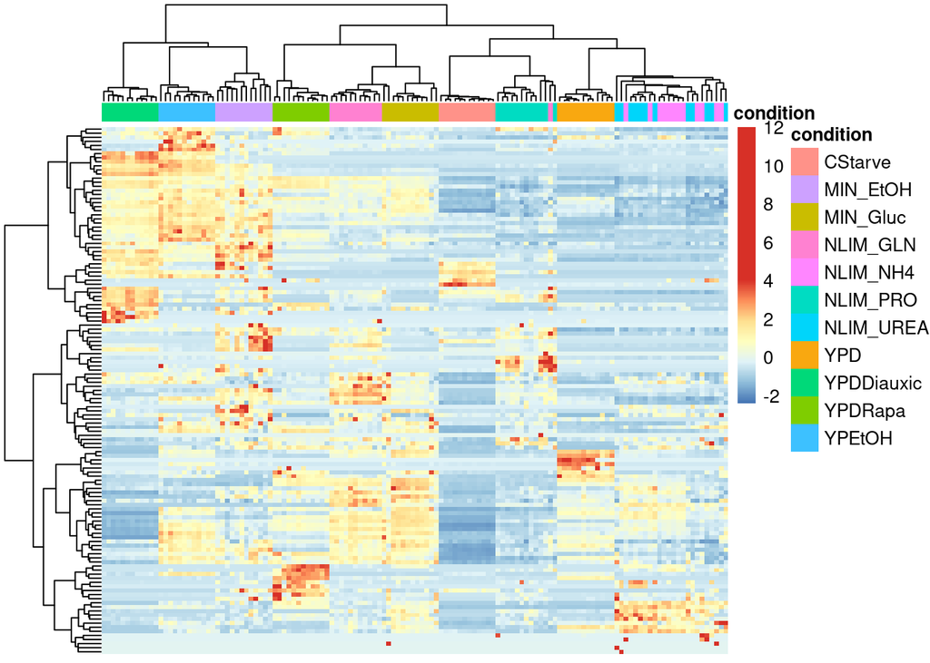

```r
# heatmap of activities, where groups of TFs are shown in rectangles.
pHeat <- pheatmap(mu_tc_scaled,
         show_rownames=FALSE, show_colnames=FALSE,
         annotation_col=annoCol, col=color,
         breaks=breaks, clustering_method = "ward.D2")
```

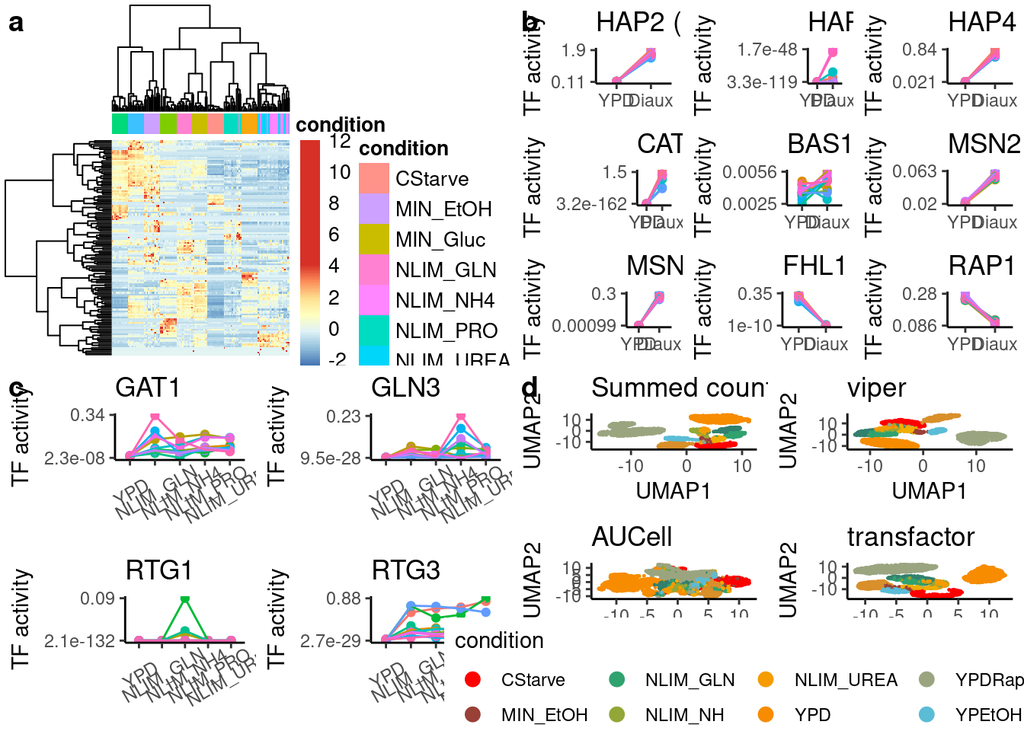

```r
pDiaux <- cowplot::plot_grid(plotlist = pListDiaux)
pNitro <- cowplot::plot_grid(plotlist = pListNitro)

pDRLeg <- cowplot::plot_grid(pDR, leg, nrow=2, ncol=1, rel_heights=c(0.9,0.2))

saveRDS(pHeat, file="../plots/pHeatTFAct_copyReproduc.rds")
saveRDS(pDiaux, file="../plots/pDiaux_copyReproduc.rds")
saveRDS(pNitro, file="../plots/pNitro_copyReproduc.rds")
saveRDS(pDR, file="../plots/pDR_copyReproduc.rds")
saveRDS(pDRLeg, file="../plots/pDRLeg_copyReproduc.rds")

cowplot::plot_grid(pHeat[[4]], pDiaux, pNitro, pDRLeg, labels=letters[1:4])
```

```r
ggsave("../plots/compositeFigure_copyReproduc.pdf", width=12, height=12)
```